# R for Spatial Data Analysis

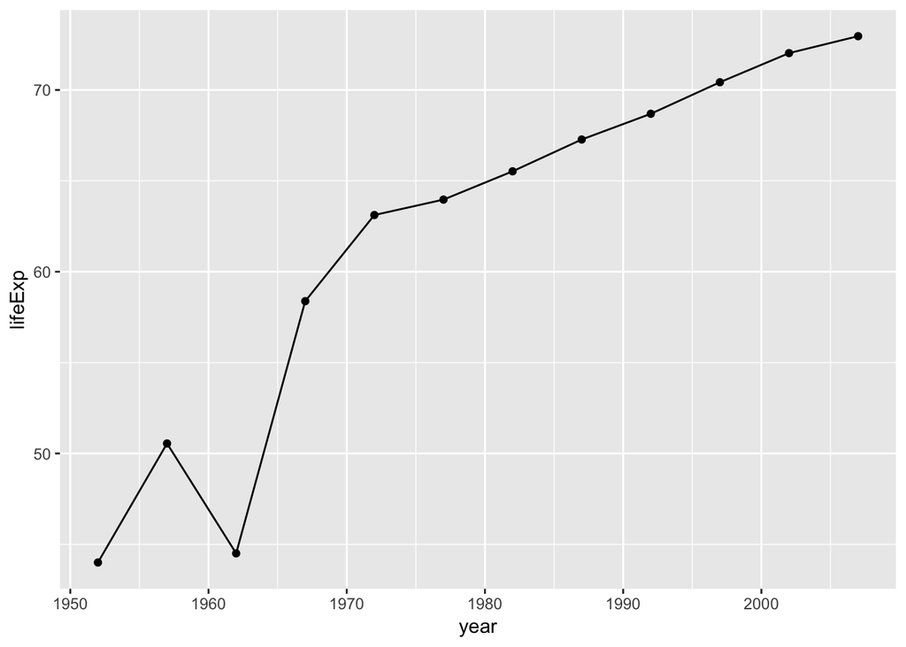

```r
ggplot(data = china.surveys, aes(x = year, y = lifeExp)) +
  geom_point() +
  geom_line()
```

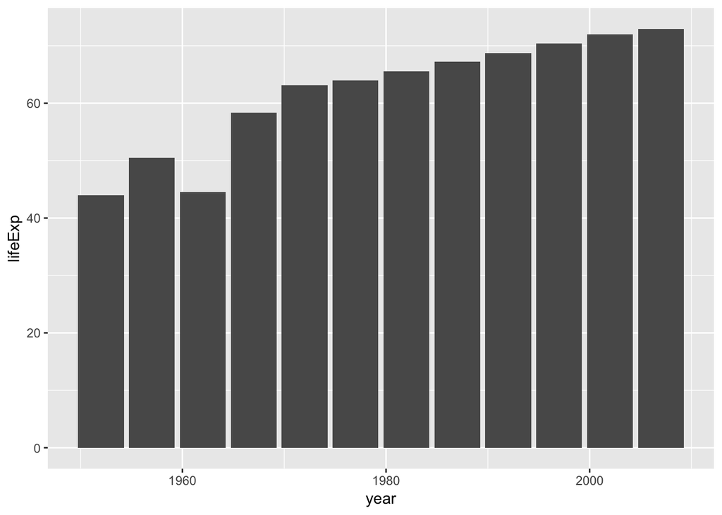

```r
base <- ggplot(data = china.surveys, aes(x = year, y = lifeExp))
base + geom_bar(stat = 'identity')
```

Some things to note:

- Anything you put in the `ggplot()` function can be seen by any `geom` layers that you add. i.e. these are universal plot settings. This includes the `x` and `y` axis you set up in `aes()`.
- You can also specify aesthetics for a given geom independently of the aesthetics defined globally in the `ggplot()` function.

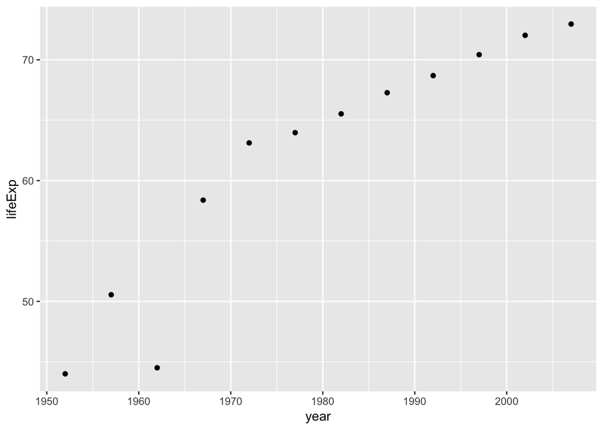

```r
ggplot(data = china.surveys) +
 geom_point(aes(x = year, y = lifeExp))
```

## Building Plots Iteratively

Building plots with `ggplot2` is typically an iterative process. We start by defining the dataset we’ll use, lay the axes, and choose a geometric object.

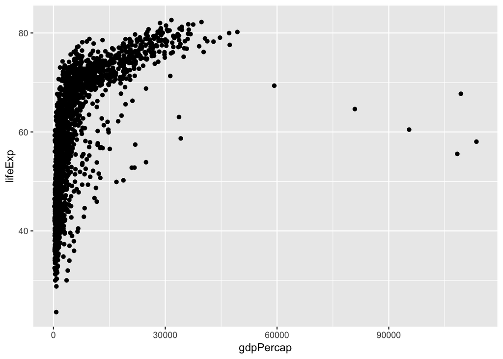

```r
ggplot(data = surveys, aes(x = gdpPercap, y = lifeExp)) +
  geom_point()
```

Then, we start modifying this plot to extract more infromation from it. For instance, we can add transparency (alpha) to avoid overplotting.

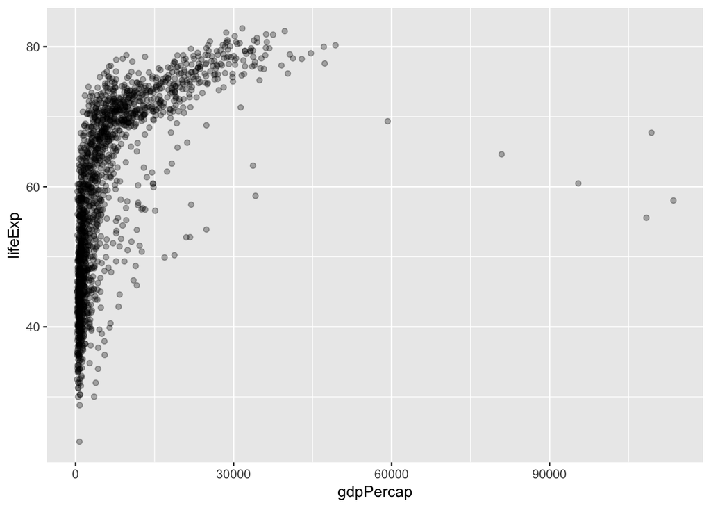

```r
ggplot(data = surveys, aes(x = gdpPercap, y = lifeExp)) +
  geom_point(alpha = 0.3)
```

We can also add a color to the point. **Note that when these options are set outside of the aesthetics (outside of the `aes()` function), they apply uniformly to all data points, whereas those inside the aesthetics vary with the values in the data.**

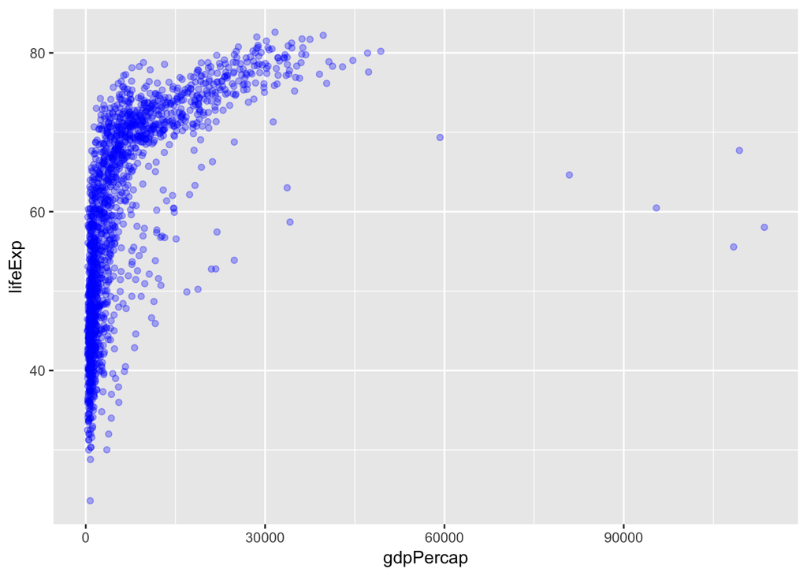

```r
ggplot(data = surveys, aes(x = gdpPercap, y = lifeExp)) +
  geom_point(alpha = 0.3, color = 'blue')
```

**If we want color to vary with the values in our data frame, we need to assign a column of the data frame as the source for those values and then map those values onto an aesthetic within the `aes()` function.** For instance, let’s let color vary by continent.

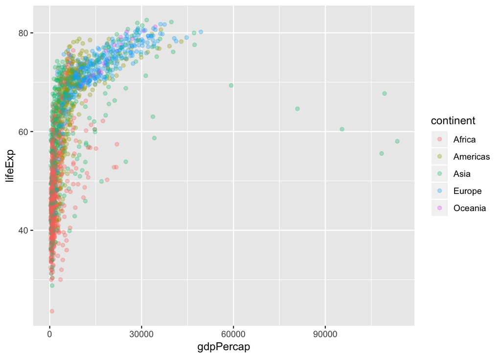

```r
ggplot(data = surveys, aes(x = gdpPercap, y = lifeExp)) +
  geom_point(alpha = 0.3, aes(color = continent))
```

**Challenge: Changing the Scale**

In many types of data, it is important to consider the *scale* of the observations. For example, it may be worth changing the scale of the axis to better distribute the observations in the space of the plot. Changing the scale of the axes is done similarly to adding/modifying other components (i.e., by incrementally adding commands). **Represent per-capita GDP on a log-10 scale.** For a hint, look up the help documentation on `scale_x_log10()`.

# Using Spatial Data in R

Let’s take a break from `dplyr` and `ggplot2` for a moment to look at how we can open and manage spatial data files in R. Later, we’ll come back to `dplyr` and `ggplot2` when we want to clean, manipulate, and plot our spatial data.

## Reading in and Understanding Shapefiles in R

Because our Gapminder dataset presents statistics on development for all countries of the world, we want to get a Shapefile that represents national units. We’ll be using a dataset from [NaturalEarthData.com](https://www.naturalearthdata.com/downloads/110m-cultural-vectors/), a repository of vector data on cultural and physical features world-wide.

There are two packages we’ll use for opening and managing Shapefiles. The `rgdal` library is a set of general tools for reading both raster and vector data. The `sf` or “simple features” library has tools for both reading and manipulating vector data. The `sf` library depends on `rgdal` and so `rgdal` is automatically loaded when we load the `sf` library.

```r
install.packages('rgdal')
install.packages('sf')
```

```r
library(sf)
```

To import Shapefiles with the `sf` library, we use the `st_read()` function.

```r
countries <- st_read('data/r-spatial-countries/ne_110m_admin_0_countries.shp')
```

The `st_read()` function automatically stores additional information about the Shapefile we imported into R. We are particularly interested in the geospatial metadata that was printed out, which describes the format, coordinate reference system (CRS), extent, and other details. The key metadata we’re interested in include:

- **Object Type:** The class of the imported object;
- **Coordinate Reference System (CRS):** The system describing how coordinates are organized in space, sometimes called the “projection” for projected coordinate systems;
- **Extent:** The spatial extent, i.e., geographic area covered by the Shapefile.

**Question: How many countries are represented in this Shapefile?**

We can view these metdata using the following functions. First, we can see that each country is represented as a `MULTIPOLYGON` type; this means that a single row in the attribute table, corresponding to a single country, may be made up of one or more polygons. **Can you think of a reason why we might need to represent a single country using multiple polygons?**

```r
st_geometry_type(countries)
```

```
##            0            1            2            3            4
## MULTIPOLYGON MULTIPOLYGON MULTIPOLYGON MULTIPOLYGON MULTIPOLYGON
##            5            6            7            8            9
## MULTIPOLYGON MULTIPOLYGON MULTIPOLYGON MULTIPOLYGON MULTIPOLYGON
##           10           11           12           13           14
## MULTIPOLYGON MULTIPOLYGON MULTIPOLYGON MULTIPOLYGON MULTIPOLYGON
##           15           16           17           18           19
## MULTIPOLYGON MULTIPOLYGON MULTIPOLYGON MULTIPOLYGON MULTIPOLYGON
##           20           21           22           23           24
## MULTIPOLYGON MULTIPOLYGON MULTIPOLYGON MULTIPOLYGON MULTIPOLYGON
##           25           26           27           28           29
## MULTIPOLYGON MULTIPOLYGON MULTIPOLYGON MULTIPOLYGON MULTIPOLYGON
##           30           31           32           33           34
## MULTIPOLYGON MULTIPOLYGON MULTIPOLYGON MULTIPOLYGON MULTIPOLYGON
##           35           36           37           38           39
## MULTIPOLYGON MULTIPOLYGON MULTIPOLYGON MULTIPOLYGON MULTIPOLYGON
##           40           41           42           43           44
## MULTIPOLYGON MULTIPOLYGON MULTIPOLYGON MULTIPOLYGON MULTIPOLYGON
##           45           46           47           48           49
## MULTIPOLYGON MULTIPOLYGON MULTIPOLYGON MULTIPOLYGON MULTIPOLYGON
##           50           51           52           53           54
## MULTIPOLYGON MULTIPOLYGON MULTIPOLYGON MULTIPOLYGON MULTIPOLYGON
##           55           56           57           58           59
## MULTIPOLYGON MULTIPOLYGON MULTIPOLYGON MULTIPOLYGON MULTIPOLYGON
##           60           61           62           63           64
## MULTIPOLYGON MULTIPOLYGON MULTIPOLYGON MULTIPOLYGON MULTIPOLYGON
##           65           66           67           68           69
## MULTIPOLYGON MULTIPOLYGON MULTIPOLYGON MULTIPOLYGON MULTIPOLYGON
##           70           71           72           73           74
## MULTIPOLYGON MULTIPOLYGON MULTIPOLYGON MULTIPOLYGON MULTIPOLYGON
##           75           76           77           78           79
## MULTIPOLYGON MULTIPOLYGON MULTIPOLYGON MULTIPOLYGON MULTIPOLYGON
##           80           81           82           83           84
## MULTIPOLYGON MULTIPOLYGON MULTIPOLYGON MULTIPOLYGON MULTIPOLYGON
##           85           86           87           88           89
## MULTIPOLYGON MULTIPOLYGON MULTIPOLYGON MULTIPOLYGON MULTIPOLYGON
##           90           91           92           93           94
## MULTIPOLYGON MULTIPOLYGON MULTIPOLYGON MULTIPOLYGON MULTIPOLYGON
##           95           96           97           98           99
## MULTIPOLYGON MULTIPOLYGON MULTIPOLYGON MULTIPOLYGON MULTIPOLYGON
```

[output cut: 18 more lines]

```
##          145          146          147          148          149
## MULTIPOLYGON MULTIPOLYGON MULTIPOLYGON MULTIPOLYGON MULTIPOLYGON
##          150          151          152          153          154
## MULTIPOLYGON MULTIPOLYGON MULTIPOLYGON MULTIPOLYGON MULTIPOLYGON
##          155          156          157          158          159
## MULTIPOLYGON MULTIPOLYGON MULTIPOLYGON MULTIPOLYGON MULTIPOLYGON
##          160          161          162          163          164
## MULTIPOLYGON MULTIPOLYGON MULTIPOLYGON MULTIPOLYGON MULTIPOLYGON
##          165          166          167          168          169
## MULTIPOLYGON MULTIPOLYGON MULTIPOLYGON MULTIPOLYGON MULTIPOLYGON
##          170          171          172          173          174
## MULTIPOLYGON MULTIPOLYGON MULTIPOLYGON MULTIPOLYGON MULTIPOLYGON
##          175          176
## MULTIPOLYGON MULTIPOLYGON
## 18 Levels: GEOMETRY POINT LINESTRING POLYGON ... TRIANGLE
```

**Also, note at the bottom of this output is a list of the 18 different geometry types supported by this library;** they’re listed here because our `MULTIPOLYGON` type is just one level in this category.

```r
st_crs(countries)
```

```
## Coordinate Reference System:
##   EPSG: 4326
##   proj4string: "+proj=longlat +datum=WGS84 +no_defs"
```

We can see the CRS is unprojected latitude-longitude coordinates, using the WGS84 datum.

```r
st_bbox(countries)
```

```
##       xmin       ymin       xmax       ymax
## -180.00000  -90.00000  180.00000   83.64513
```

[Here’s a figure depicting what the bounding box (“bbox”) or extent of a vector dataset looks like.](https://datacarpentry.org/r-raster-vector-geospatial/images/dc-spatial-vector/spatial_extent.png)

Finally, we can view all these metadata at once, again, by simply printing our dataset to the screen.

```r
countries
```

```
## Simple feature collection with 177 features and 94 fields
## geometry type:  MULTIPOLYGON
## dimension:      XY
## bbox:           xmin: -180 ymin: -90 xmax: 180 ymax: 83.64513
## epsg (SRID):    4326
## proj4string:    +proj=longlat +datum=WGS84 +no_defs
## First 10 features:
##         featurecla scalerank LABELRANK                  SOVEREIGNT SOV_A3
## 1  Admin-0 country         1         6                        Fiji    FJI
## 2  Admin-0 country         1         3 United Republic of Tanzania    TZA
## 3  Admin-0 country         1         7              Western Sahara    SAH
## 4  Admin-0 country         1         2                      Canada    CAN
## 5  Admin-0 country         1         2    United States of America    US1
## 6  Admin-0 country         1         3                  Kazakhstan    KAZ
## 7  Admin-0 country         1         3                  Uzbekistan    UZB
```

[output cut: 234 more lines]

## Plotting Shapefiles in R

Now, let’s visualize the data in our `sf` object using the `ggplot2` package.

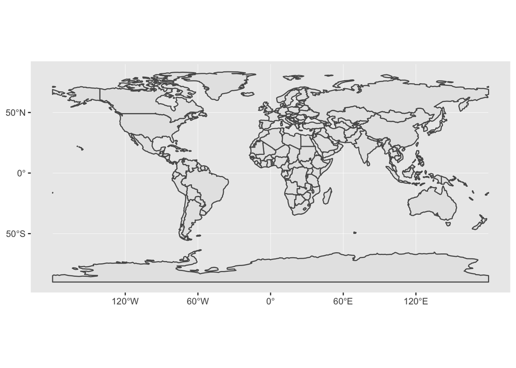

```r
ggplot() +
  geom_sf(data = countries) +
  coord_sf()
```

As with the previous `ggplot2` examples, we can customize the many aesthetics of our `countries` layer.

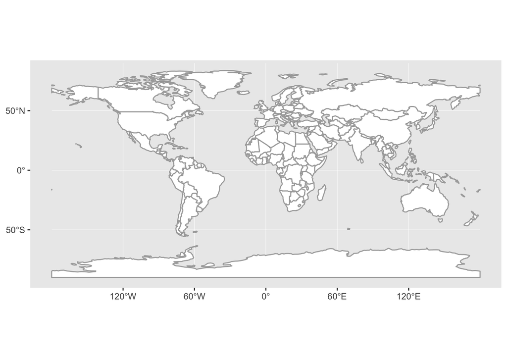

```r
ggplot() +
  geom_sf(data = countries, color = 'darkgray', fill = 'white') +
  coord_sf()
```

**What map projection is this?** When we have latitude-longitude data, the most basic plot we can construct treats every degree of latitude or longitude as an equal, rectangular unit of a grid; thus, it’s called an “equirectangular” plot.

If we want to plot just a portion of our Shapefile, we need to filter the dataset to that particular subset. As we saw earlier, this is something the `dplyr` library can help with.

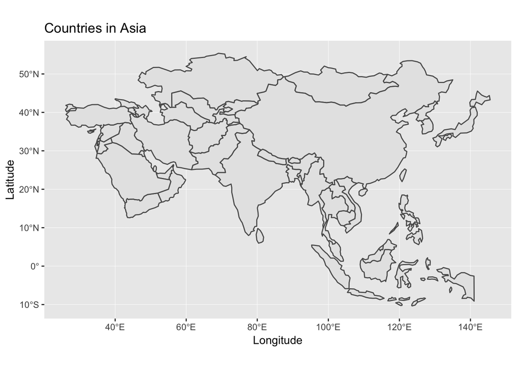

```r
ggplot() +
  geom_sf(data = filter(countries, REGION_UN == 'Asia')) +
  labs(x = 'Longitude', y = 'Latitude', title = 'Countries in Asia')
```

```r
  coord_sf()
```

[output not shown]

## Capstone: Creating a Choropleth Map

Ultimately, we want to merge this Shapefile with our Gapminder data so we can create a choropleth map showing something like per-capita GDP across countries. Currently, there are quite a lot of extraneous attributes in our Shapefile. We’ll want to create a minimal subset of columns, first.

```r
names(countries)
```

```
##  [1] "featurecla" "scalerank"  "LABELRANK"  "SOVEREIGNT" "SOV_A3"
##  [6] "ADM0_DIF"   "LEVEL"      "TYPE"       "ADMIN"      "ADM0_A3"
## [11] "GEOU_DIF"   "GEOUNIT"    "GU_A3"      "SU_DIF"     "SUBUNIT"
## [16] "SU_A3"      "BRK_DIFF"   "NAME"       "NAME_LONG"  "BRK_A3"
## [21] "BRK_NAME"   "BRK_GROUP"  "ABBREV"     "POSTAL"     "FORMAL_EN"
## [26] "FORMAL_FR"  "NAME_CIAWF" "NOTE_ADM0"  "NOTE_BRK"   "NAME_SORT"
## [31] "NAME_ALT"   "MAPCOLOR7"  "MAPCOLOR8"  "MAPCOLOR9"  "MAPCOLOR13"
## [36] "POP_EST"    "POP_RANK"   "GDP_MD_EST" "POP_YEAR"   "LASTCENSUS"
## [41] "GDP_YEAR"   "ECONOMY"    "INCOME_GRP" "WIKIPEDIA"  "FIPS_10_"
## [46] "ISO_A2"     "ISO_A3"     "ISO_A3_EH"  "ISO_N3"     "UN_A3"
## [51] "WB_A2"      "WB_A3"      "WOE_ID"     "WOE_ID_EH"  "WOE_NOTE"
## [56] "ADM0_A3_IS" "ADM0_A3_US" "ADM0_A3_UN" "ADM0_A3_WB" "CONTINENT"
## [61] "REGION_UN"  "SUBREGION"  "REGION_WB"  "NAME_LEN"   "LONG_LEN"
## [66] "ABBREV_LEN" "TINY"       "HOMEPART"   "MIN_ZOOM"   "MIN_LABEL"
## [71] "MAX_LABEL"  "NE_ID"      "WIKIDATAID" "NAME_AR"    "NAME_BN"
## [76] "NAME_DE"    "NAME_EN"    "NAME_ES"    "NAME_FR"    "NAME_EL"
## [81] "NAME_HI"    "NAME_HU"    "NAME_ID"    "NAME_IT"    "NAME_JA"
## [86] "NAME_KO"    "NAME_NL"    "NAME_PL"    "NAME_PT"    "NAME_RU"
## [91] "NAME_SV"    "NAME_TR"    "NAME_VI"    "NAME_ZH"    "geometry"
```

```r
head(countries)
```

```
## Simple feature collection with 6 features and 94 fields
## geometry type:  MULTIPOLYGON
## dimension:      XY
## bbox:           xmin: -180 ymin: -18.28799 xmax: 180 ymax: 83.23324
## epsg (SRID):    4326
## proj4string:    +proj=longlat +datum=WGS84 +no_defs
##        featurecla scalerank LABELRANK                  SOVEREIGNT SOV_A3
## 1 Admin-0 country         1         6                        Fiji    FJI
## 2 Admin-0 country         1         3 United Republic of Tanzania    TZA
## 3 Admin-0 country         1         7              Western Sahara    SAH
## 4 Admin-0 country         1         2                      Canada    CAN
## 5 Admin-0 country         1         2    United States of America    US1
## 6 Admin-0 country         1         3                  Kazakhstan    KAZ
##   ADM0_DIF LEVEL              TYPE                       ADMIN ADM0_A3
## 1        0     2 Sovereign country                        Fiji     FJI
```

[output cut: 138 more lines]

```r
countries.asia <- countries %>%
  select(name = NAME, a3_code = SOV_A3, region = REGION_UN, subregion = SUBREGION) %>%
  filter(region == 'Asia')
countries.asia
```

```
## Simple feature collection with 47 features and 4 fields
## geometry type:  MULTIPOLYGON
## dimension:      XY
## bbox:           xmin: 26.04335 ymin: -10.35999 xmax: 145.5431 ymax: 55.38525
## epsg (SRID):    4326
## proj4string:    +proj=longlat +datum=WGS84 +no_defs
## First 10 features:
##                    name a3_code region          subregion
## 1            Kazakhstan     KAZ   Asia       Central Asia
## 2            Uzbekistan     UZB   Asia       Central Asia
## 3             Indonesia     IDN   Asia South-Eastern Asia
## 4           Timor-Leste     TLS   Asia South-Eastern Asia
## 5                Israel     IS1   Asia       Western Asia
## 6               Lebanon     LBN   Asia       Western Asia
## 7             Palestine     IS1   Asia       Western Asia
## 8                Jordan     JOR   Asia       Western Asia
## 9  United Arab Emirates     ARE   Asia       Western Asia
## 10                Qatar     QAT   Asia       Western Asia
##                          geometry
## 1  MULTIPOLYGON (((87.35997 49...
## 2  MULTIPOLYGON (((55.96819 41...
## 3  MULTIPOLYGON (((141.0002 -2...
## 4  MULTIPOLYGON (((124.9687 -8...
## 5  MULTIPOLYGON (((35.71992 32...
## 6  MULTIPOLYGON (((35.8211 33....
## 7  MULTIPOLYGON (((35.39756 31...
## 8  MULTIPOLYGON (((35.54567 32...
## 9  MULTIPOLYGON (((51.57952 24...
## 10 MULTIPOLYGON (((50.81011 24...
```

We’re going to use `ggplot2` for plotting, again, so that we have more sophisticated control over the map we create. However, it’s helpful to note that the built-in R function `plot()` does work with the `sf` objects; by default, it will create a very simple choropleth map for every column in the attribute table, which might be useful for exploring patterns over multiple variables.

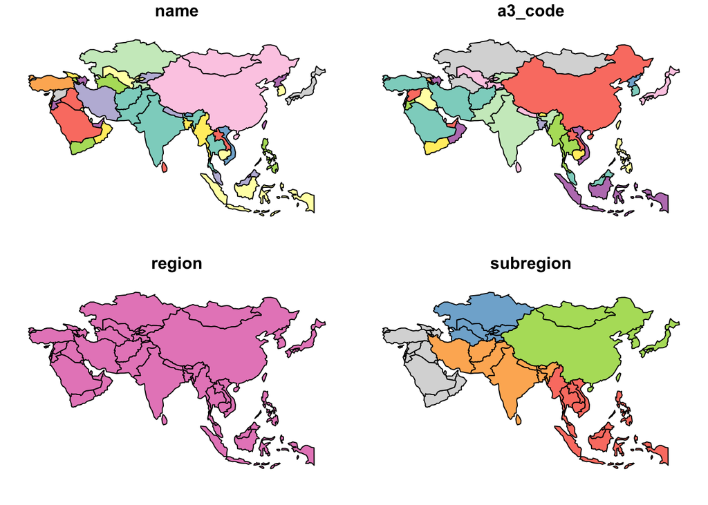

```r
plot(countries.asia)
```

Now, we’re ready to make a simple choropleth map; here’s an example map of the subregions of Asia. Remember that to tell ggplot to base aesthetics on data *in the table,* we need to use the `aes()` function.

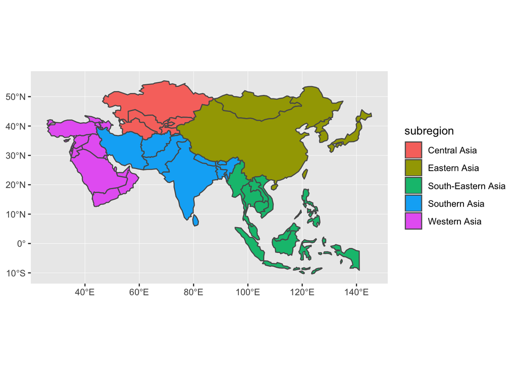

```r
ggplot() +
  geom_sf(data = countries.asia, aes(fill = subregion)) +
  coord_sf()
```

### Joining Data

**In order to plot our Gapminder data using the Shapefile we imported, we’re going to have to join the two datasets together.** With the `dplyr` library, this can be accomplished with functions like `left_join()`.

```r
surveys.2007 <- filter(surveys, year == 2007)

countries.asia.2007 <- countries.asia %>%
  rename(country = name) %>%
  left_join(surveys.2007, by = 'country')
```

Unfortunately, the Gapminder dataset does not include all of the countries of the world, due to changing national status and boundaries. We might wonder how many countries have been left out of this join; we can use `dplyr` again to query this.

```r
countries.asia.2007 %>%
  filter(is.na(lifeExp)) %>%
  View
```

### Capstone Challenge: Choropleth of Gapminder Data

Now, you can apply what you’ve learned about:

- Grouping and summarizing a data frame using `dplyr`;
- Plotting a Shapefile with `ggplot2`;
- Joining two datasets together with `dplyr` and `left_join()`;

**Make a choropleth map of either life expectancy (`lifeExp`) or per-capita GDP (`gdpPercap`) in Asia in 2007, or in any other region of the world in any year, using what you’ve learned.**

# Conclusion and Summary

## Related Topics

### Creating Simple Features from Text Data

**The `st_as_sf()` function is also used for taking non-spatial datasets like CSV files and transforming them into spatial data.**

```r
oxford <- data.frame(name = 'Oxford, Ohio', x = -84.746667, y = 39.5075)
st_as_sf(oxford, coords = c('x', 'y'), crs = st_crs(4326))
```

```
## Simple feature collection with 1 feature and 1 field
## geometry type:  POINT
## dimension:      XY
## bbox:           xmin: -84.74667 ymin: 39.5075 xmax: -84.74667 ymax: 39.5075
## epsg (SRID):    4326
## proj4string:    +proj=longlat +datum=WGS84 +no_defs
##           name                  geometry
## 1 Oxford, Ohio POINT (-84.74667 39.5075)
```

## Other Resources

- [Quick-R](http://www.statmethods.net/): “An easily accessible reference…for both current R users, and experienced users of other statistical packages…who would like to transition to R.”
- [RStudio Cheat Sheets](https://www.rstudio.com/resources/cheatsheets/): A list of informational graphics that help remind you how to use some advanced features in RStudio.
- [The R Inferno](http://www.burns-stat.com/pages/Tutor/R_inferno.pdf): A humorous and informative guide to some of the more advanced features and confounding behavior.
- [Writing (Fast) Loops in R](http://faculty.washington.edu/kenrice/sisg/SISG-08-05.pdf)
- [dplyr Cheat Sheet](http://www.rstudio.com/wp-content/uploads/2015/02/data-wrangling-cheatsheet.pdf)
- A longer introduction to `plyr` and `dplyr` [using the same Gapminder data](http://stat545.com/block009_dplyr-intro.html).
- More on using `dplyr` [to analyze the Gapminder data](http://stat545.com/block010_dplyr-end-single-table.html).